# Adult Index Estimation

Jean V. Adams

2018-08-12

One overarching function, `AIpresto` can be used to carry out all the steps of the Adult Index estimation process in one fell swoop. This function prepares and error checks the data, estimates the Adult Index, calculates the targets, and generates a draft report.

## Install

Install the latest version of **[R](https://www.r-project.org/)** from [CRAN](https://cran.r-project.org/bin/windows/base/).

Install the latest version of the **GLFC** package following the instructions at [Readme](https://github.com/JVAdams/GLFC/blob/master/README.md). The easiest way to do this, if you already have the package **devtools** installed, is:

```r
devtools::install_github("JVAdams/GLFC")
```

## Prepare the data

Three csv files are needed to generate Adult Index estimates, one each with new stream data, previous stream data, and previous lake data.

**(1)** `STREAMDATANEW` should contain stream mark-recapture estimates of adult sea lampreys for the year of interest.

| year | lake | lscode | trapcatch | PEmr | CVmr | comments |
| --- | --- | --- | --- | --- | --- | --- |
| 2015 | 1 | 1.032 | 1 | NA | NA | no recaps |
| 2015 | 2 | 2.005 | 5971 | 9121 | 6 |  |
| 2015 | 2 | 2.006 | 575 | 910 | 16 |  |
| 2015 | 2 | 2.015 | 619 | 1548 | 9 |  |
| 2015 | 2 | 2.024 | 1010 | 1316 | 12 |  |

The first row of `STREAMDATANEW` should be a header row with the following column names:

- `year` - survey year
- `lake` - lake code (1=Superior, 2=Michigan, 3=Huron, 4=Erie, and 5=Ontario)
- `lscode` - lake-stream code, a combination of lake and stream codes e.g., lscode = 1.064 = lake code + (stream code)/1000
- `trapcatch` = no. of adult sea lampreys captured
- `PEmr` = stream population estimate of adult sea lampreys from mark-recapture study
- `CVmr` = coefficient of variation of PEmr
- `comments` = comments

where
$$CV_{mr} = 100\% \frac{\sqrt{Var(PE_{mr})}}{PE_{mr}}$$

**(2)** `STREAMDATAPREV` should contain stream mark-recapture estimates of adult sea lampreys for all of the years prior to the year of interest.

| year | lake | lscode | PEmr | CVmr | indexContrib | indexContribCV |
| --- | --- | --- | --- | --- | --- | --- |
| 2000 | 1 | 1.026 | NA | NA | NA | NA |
| 2001 | 1 | 1.026 | NA | NA | NA | NA |
| 1989 | 1 | 1.028 | NA | NA | NA | NA |
| 1990 | 1 | 1.028 | NA | NA | NA | NA |
| 1991 | 1 | 1.028 | NA | NA | NA | NA |

The first row of `STREAMDATAPREV` should be a header row with the following column names:

- `year` - survey year
- `lake` - lake code
- `lscode` - lake-stream code, a combination of lake and stream codes
- `PEmr` = stream population estimate of adult sea lampreys from mark-recapture study
- `CVmr` = coefficient of variation
- `indexContrib` = the stream population estimate used in the Adult Index
- `indexContribCV` = the stream CV used in the 95% confidence interval

**(3)** `LAKEDATAPREV` should contain annual lake-wide adult sea lamprey indices for all of the years prior to the year of interest.

| year | lake | index | ilo | ihi |
| --- | --- | --- | --- | --- |
| 2010 | 5 | 14864 | 11176 | 18552 |
| 2011 | 5 | 24808 | 15232 | 34384 |
| 2012 | 5 | 25848 | 21379 | 30318 |
| 2013 | 5 | 9456 | 7532 | 11380 |
| 2014 | 5 | 10644 | 8435 | 12854 |

The first row of `LAKEDATAPREV` should be a header row with the following column names:

- `year` - survey year
- `lake` - lake code
- `index` - estimated lake-wide index of adult sea lamprey abundance
- `ilo` - lower 95% confidence interval
- `ihi` - upper 95% confidence interval

For all 3 files,

- the names of the columns must be **exactly as described here** (same spelling, same case)
- the order of the columns is not important
- additional columns may be included
- there should be no missing values in `year`, `lake`, or `lscode`

All 3 files should all be stored in a single directory, `DIRECTORY`.

Assign the name of the directory (use double backslashes, \\, in the file path) and the names of the three files. For example,

```r
Dir <- "C:\\temp"
StreamNew <- "AdultStream2015.csv"
StreamPrev <- "AdultStreamThru2014.csv"
LakePrev <- "AdultLakeThru2014.csv"
```

## Run the works

Load the **GLFC** package to have access to the Adult Index functions.

```r
library(GLFC)
```

Use the `AIpresto()` function to prepare and error check the data, estimate the Adult Index, calculate the targets, and generate a draft report. Simply provide the function with the name of the directory where the files are stored, the names of the new and previous stream data, and the name of the previous lake data.

```r
AIpresto(DIRECTORY=Dir, NEWDATARAW=StreamNew, STREAMDATAPREV=StreamPrev, LAKEDATAPREV=LakePrev)
```

## Behind the scenes

Within the `AIpresto()` function, the following steps are carried out.

### Manipulate the data

The `AIprep()` function is used to read in the adult sea lamprey stream trapping data and prepare them for error checking and estimation.

```r
streamall <- AIprep(csvDir=Dir, csvNew=StreamNew, csvOld=StreamPrev)
```

The `AIprep()` function brings in additional information built in to the **GLFC** package by default, including

- `trappedStreams` a data frame with stream information,

| lake | lscode | country | strcode | estr | strname | lat | long |
| --- | --- | --- | --- | --- | --- | --- | --- |
| 1 | 1.060 | Canada | 60 | 4 | Little Carp | 46.50 | -84.43 |
| 1 | 1.059 | Canada | 59 | 5 | Big Carp | 46.50 | -84.45 |
| 1 | 1.072 | Canada | 72 | 23 | Cranberry | 46.70 | -84.43 |
| 1 | 1.058 | Canada | 58 | 24 | Goulais | 46.71 | -84.45 |
| 1 | 1.071 | Canada | 71 | 39 | Harmony | 46.85 | -84.36 |

- `lsIndex` a list of lake-stream codes identifying index streams,

| lake | index.streams |
| --- | --- |
| Superior | 1.001, 1.002, 1.009, 1.029, 1.031, 1.032, 1.062 |
| Michigan | 2.005, 2.006, 2.015, 2.024, 2.026, 2.035 |
| Huron | 3.01, 3.016, 3.027, 3.032, 3.999, 3.038 |
| Erie | 4.001, 4.002, 4.003, 4.007, 4.009 |
| Ontario | 5.005, 5.009, 5.022, 5.023, 5.036 |

- `lsKeep` a list of lake-stream codes identifying streams which will continue to have ongoing trapping even if not part of the Adult Index.

| lake | maintenance.streams |
| --- | --- |
| All | 1.023, 1.059, 2.013, 2.068, 4.001, 5.013, 5.021 |

The returned object from the `AIprep()` function is a single data frame (called `streamall` in this example) with information from all of the inputs, including new variables:

- `index` - a logical (TRUE/FALSE) identifying the index streams
- `maintain` - a logical identifying the streams that will continue to have ongoing trapping even if not part of the Adult Index
- `indexContrib` - the stream population estimate that will be used in the Adult Index (initially set to missing for `csvNew`)
- `indexContribCV` - the stream CV that will be used in the 95% confidence interval (initially set to missing for `csvNew`)
- `complete` - a logical identifying streams and years for which the Adult Index has already been estimated (initially set to FALSE for `csvNew`)

| lscode | year | trapcatch | PEmr | CVmr | comments | index | maintain | complete | indexContrib | indexContribCV | lake | country | strcode | estr | strname | lat | long |
| --- | --- | --- | --- | --- | --- | --- | --- | --- | --- | --- | --- | --- | --- | --- | --- | --- | --- |
| 5.036 | 2010 | 252 | 1242 | 18 | NA | TRUE | FALSE | TRUE | 1242 | 18 | 5 | US | 36 | 73 | Sterling | 43.34 | -76.69 |
| 5.036 | 2011 | 85 | 703 | 39 | NA | TRUE | FALSE | TRUE | 703 | 39 | 5 | US | 36 | 73 | Sterling | 43.34 | -76.69 |
| 5.036 | 2012 | 36 | NA | NA | NA | TRUE | FALSE | TRUE | 1726 | 35 | 5 | US | 36 | 73 | Sterling | 43.34 | -76.69 |
| 5.036 | 2013 | 280 | 938 | 18 | NA | TRUE | FALSE | TRUE | 938 | 18 | 5 | US | 36 | 73 | Sterling | 43.34 | -76.69 |
| 5.036 | 2014 | 216 | 847 | 31 | NA | TRUE | FALSE | TRUE | 847 | 31 | 5 | US | 36 | 73 | Sterling | 43.34 | -76.69 |

### Error checking the data

The `AIcheck()` function is used to check the data for errors and generate a report of tables and figures.

```r
AIcheck(streamDat=streamall, csvDir=Dir)
```

```
## New RTF document created, C:\temp/2015 Adult Index - error checking.doc
```

The generated report is an *rtf* (rich text format) file but it has a *.doc extension so that it will be automatically opened by Microsoft Word. The report is named `YYYY Adult Index - error checking.doc`, where *YYYY* is the latest year represented in `streamDat`, and placed in the directory `csvDir`. In this example, the path to the error checking report is `C:\temp\2015 Adult Index - error checking.doc`.

The following conditions are highlighted as potential errors in the data:

- mark-recapture estimates without trap catches or CVs
- population estimates less than trap catches
- for the most recent year
  - streams missing population estimates or CVs
  - unusually large trap catches
  - unusually small trap catches

The error checking report also includes two multi-panel (one panel per stream) time series plots:

- adult sea lamprey trap efficiency estimates (trap catch / mark-recapture PE)

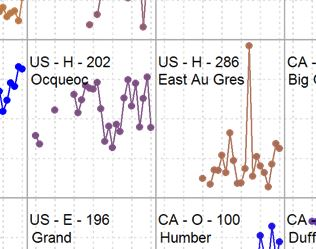

- adult sea lamprey mark-recapture estimates

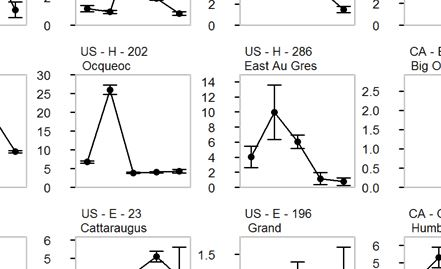

### Estimating the Adult Index

The `AIestimate()` function is used to estimate the Adult Index of sea lampreys in a single Great Lake. For example, for Lake Ontario,

```r
ainewOnt <- AIestimate(streamDat=streamall[streamall$lake==5, ])
```

The annual Adult Index is simply the sum of stream population estimates for each year. Missing stream estimates are estimated by a lake-specific ANOVA model relating the log of the stream estimates to the main effects of each stream and each year, weighted by the inverse of the CV squared.

The 95% confidence interval is estimated from the sum of the mark-recapture variances of the streams.

The returned object from the function (`ainewOnt` in this example) is a list with 2 components:

- `streamPE` - a data frame of stream mark-recapture and Adult Index contributions for the incomplete rows in `streamDat`, with the same variables as `streamDat`

| lscode | year | trapcatch | PEmr | CVmr | comments | index | maintain | complete | indexContrib | indexContribCV | lake | country | strcode | estr | strname | lat | long |
| --- | --- | --- | --- | --- | --- | --- | --- | --- | --- | --- | --- | --- | --- | --- | --- | --- | --- |
| 5.005 | 2015 | 233 | 441 | 45.35 | NA | TRUE | FALSE | TRUE | 441 | 45 | 5 | Canada | 5 | 117 | Duffins | 43.81 | -79.03 |
| 5.009 | 2015 | 25 | NA | NA | no recaps | TRUE | FALSE | TRUE | 893 | 29 | 5 | Canada | 9 | 131 | Bowmanville | 43.88 | -78.66 |
| 5.022 | 2015 | 1249 | 1733 | 12.51 | NA | TRUE | FALSE | TRUE | 1733 | 13 | 5 | Canada | 22 | 100 | Humber | 43.63 | -79.47 |
| 5.023 | 2015 | 2316 | 6434 | 8.00 | NA | TRUE | FALSE | TRUE | 6434 | 8 | 5 | US | 23 | 19 | Black | 43.99 | -76.06 |
| 5.036 | 2015 | 149 | 797 | 25.00 | NA | TRUE | FALSE | TRUE | 797 | 25 | 5 | US | 36 | 73 | Sterling | 43.34 | -76.69 |

- `lakeIndex` - a data frame of annual lake-wide Adult Indices with 5 columns: `lake`, `year`, `index`, and the 95% confidence intervals `ilo` and `ihi`

| lake | year | index | ilo | ihi |
| --- | --- | --- | --- | --- |
| 5 | 2015 | 10297.93 | 8557.329 | 12038.52 |

The index estimates for the lakes, `lakeainew`, looks like this:

| lake | year | index | ilo | ihi |
| --- | --- | --- | --- | --- |
| 1 | 2015 | 20224.32 | 10152.318 | 30296.32 |
| 2 | 2015 | 14695.00 | 12772.938 | 16617.06 |
| 3 | 2015 | 23968.00 | 20539.559 | 27396.44 |
| 4 | 2015 | 7112.00 | 2755.585 | 11468.41 |
| 5 | 2015 | 10297.93 | 8557.329 | 12038.52 |

### Determining the targets

The `AItarget()` function is used to calculate lake-wide targets for the Adult Index of sea lamprey populations in the Great Lakes from the mean of specified years. The `AItarget()` function takes three arguments, but only the first one needs to be provided.

```r
targ <- AItarget(lakeIndex=lakeprev)
```

- `lakeIndex` - a data frame of annual lake-wide Adult Indices with (at least these) 3 columns: `lake`, `year`, and `index`
- `years` - A list of 5 vectors (one for each Great Lake), specifying the 5 years during which there were acceptable sea lamprey wounding rates on lake trout
- `adjust` - A vector of 5 adjustments (one for each Great Lake) to be made to the mean indices when calculating the target (this is needed if the wounding rates were not acceptable during the specified years)

Default values are provided for `years` and `adjust` based on the decisions made by the Great Lakes Fishery Commission. Currently, these values are

| lake | years | adjust |
| --- | --- | --- |
| Superior | 1994-1998 | 1.0000000 |
| Michigan | 1995-1999 | 0.5617978 |
| Huron | 1989-1993 | 0.2500000 |
| Erie | 1991-1995 | 1.0000000 |
| Ontario | 1993-1997 | 1.0000000 |

| lake | targInd |
| --- | --- |
| 1 | 9664 |
| 2 | 24874 |
| 3 | 24113 |
| 4 | 3039 |
| 5 | 11368 |

### Scaling up indices to PEs

Lake-specific conversion factors built in to the **GLFC** package, `index2pe`, are used to scale up indices of adult sea lamprey abundance in the Great Lakes to lake-wide population estimates.

|  | index2pe |
| --- | --- |
| Superior | 3.95 |
| Michigan | 1.87 |
| Huron | 2.87 |
| Erie | 1.45 |
| Ontario | 2.37 |

```r
lakeall <- plyr::rbind.fill(lakeprev, lakeainew)
lakeallpe <- merge(
  lakeall[, c("lake", "year", "index", "ilo", "ihi")],
  cbind(lake=1:5, i2pe=index2pe))
lakeallpe$pe <- with(lakeallpe, index*i2pe)
lakeallpe$pelo <- with(lakeallpe, ilo*i2pe)
lakeallpe$pehi <- with(lakeallpe, ihi*i2pe)
knitr::kable(tail(lakeallpe, 5), row.names=FALSE)
```

| lake | year | index | ilo | ihi | i2pe | pe | pelo | pehi |
| --- | --- | --- | --- | --- | --- | --- | --- | --- |
| 5 | 2002 | 15675.00 | 11527.165 | 19822.83 | 2.37 | 37149.75 | 27319.38 | 46980.12 |
| 5 | 2003 | 11378.00 | 8827.062 | 13928.94 | 2.37 | 26965.86 | 20920.14 | 33011.58 |
| 5 | 2004 | 32586.00 | 22271.373 | 42900.63 | 2.37 | 77228.82 | 52783.15 | 101674.49 |
| 5 | 2005 | 26260.00 | 20577.328 | 31942.67 | 2.37 | 62236.20 | 48768.27 | 75704.13 |
| 5 | 2015 | 10297.93 | 8557.329 | 12038.52 | 2.37 | 24406.09 | 20280.87 | 28531.30 |

### Generating a draft report

The `AIreport()` function is used to create a draft template-style report of the Adult Index estimates of sea lamprey in the Great Lakes.

```r
streamaiall <- rbind(streamall[streamall$complete==TRUE, ], streamainew)
AIreport(streamPEs=streamaiall, lakeIPEs=lakeallpe, targets=targ, csvDir=Dir)
```

```
## New RTF document created, C:\temp/2015 Adult Index - draft report.doc
```

As with the error checking report, the document generated by `AIreport()` is an *rtf* file with a *.doc extension, named `YYYY Adult Index - draft report.doc`.

The report has few paragraphs summarizing the latest estimates, along with 3 tables,

- adult sea lamprey indices for the year of interest for each lake with errors and targets
- adult sea lamprey indices for all years and all lakes
- lake-wide adult sea lamprey abundances for all years and all lakes

and 3 figures,

- 5-panel time series plot of adult sea lamprey indices (with 95% confidence intervals) and targets for each Great Lake

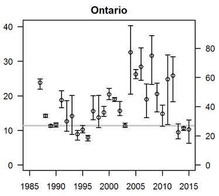

- 5-panel bar plot of adult sea lamprey abundance estimates for index streams

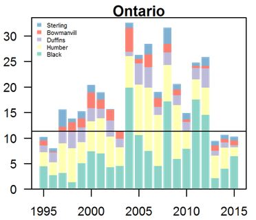

- map showing the index streams in the Great Lakes and the relative size of the most recent population estimates

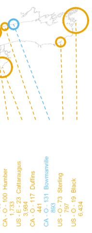

## References

- GLFC Sea Lamprey Control Board. 2016. 15-02 Meeting Action Item and Recommendation Summary. in Sea Lamprey Control Board Meeting 16-01, 12-14 Apr 2016, Briefing Item 1 - Attachment 2.
- GLFC Trapping Task Force. 2014. Transitioning to the New Adult Index in 2015. in Sea Lamprey Control Board Meeting 14-02, 15-17 Oct 2014, Briefing Item 5 - Attachment 2.
- Mullett, K. M., Heinrich, J. W., Adams, J. V., Young, R. J., Henson, M. P., McDonald, R. B., and Fodale, M. F. 2003. Estimating lake-wide abundance of spawning-phase sea lampreys (*Petromyzon marinus*) in the Great Lakes: extrapolating from sampled streams using regression models. Journal of Great Lakes Research, 29(Supplement 1), 240–252.